# Chapter 2 - Tabular data we use

Jay Skovlin, D.E. Beaudette, Stephen Roecker

February 2016

# Getting acquainted with the soilDB package

## Objectives:

- Use the soilDB package to load NASIS pedon data into R
- Learn about the checks run by the fetch functions when pulling data into R
- Learn basic commands for inspecting objects and data types
- Understand the basic structure of pedon data stored in a Soil Profile Collection (SPC)
- Learn ways to work with and inspect pedon data in R
- Learn basic checks that you can do to filter and inspect the consistency of a pedon dataset
- Not finding the data you need? Joining additional data to an SPC via extended data functions

## Contents:

- 2.1 ODBC Connection to NASIS
- 2.2 fetch functions and data checks
- 2.3 Soil Profile Collection (SPC) object
- 2.4 Viewing pedon data
- 2.5 Working with SPC data in R
- 2.6 Consistency checking pedon data in R
- 2.7 References
- 2.8 Additional resources

Examples below are meant to be copied/pasted from this document and interactively run within **R**. Comments (green text) briefly describe what the code in each line does. Further documentation on objects and functions from the `aqp` package can be accessed by typing `help(soilDB)` or `help(aqp)` (or more generally, `?function_name`) at the **R** console.

### R fundamentals

#### Data types used in R

One of the most versatile things about R is that there are many ways manipulate and work with data. Below are examples of how to create and reference information in several data types that are commonly used in working with soil data.

#### Vectors

```r
 # numeric vector example - clay %
 a <- c(10,12,15,26,30)
 # 'c()' is the concatenate function
 # values are concatenated into an object we've called 'a' by assigning the concatenate result to 'a' using '<-' or '='
 # print the values of 'a' by typing it into the R console followed by enter
 a
```

```
## [1] 10 12 15 26 30
```

```r
 # character vector - taxonomic subgroup
 b <- c("typic haplocryepts","andic haplocryepts","typic dystrocryepts")
 b
```

```
## [1] "typic haplocryepts"  "andic haplocryepts"  "typic dystrocryepts"
```

```r
 #logical vector - SPC diagnostic feature presence/absence
 c <- c(FALSE,TRUE,FALSE)
 c
```

```
## [1] FALSE  TRUE FALSE
```

#### Referencing elements of a vector

```r
 # 2nd and 4th elements of vector 'a' from above
 a
```

```
## [1] 10 12 15 26 30
```

```r
 a[c(2,4)]
```

```
## [1] 12 26
```

```r
 # 1st and 3rd elements of vector 'b' from above
 b
```

```
## [1] "typic haplocryepts"  "andic haplocryepts"  "typic dystrocryepts"
```

```r
 b[c(1,3)]
```

```
## [1] "typic haplocryepts"  "typic dystrocryepts"
```

So what’s the deal with the square bracket notation?

#### Dataframes

Dataframes are a common format that is easily crossed over to from spreadsheet formats where we are used to thinking in terms of rows and columns of data.

```r
  # Take our two character and logical vectors we created above and convert them into a more useful dataframe.
  # we'll use the data.frame() function to glue these two vectors together into object 'd'
  d <- data.frame(b, c)
  d
```

```
##                     b     c
## 1  typic haplocryepts FALSE
## 2  andic haplocryepts  TRUE
## 3 typic dystrocryepts FALSE
```

We can see that the dataframe was created and it worked but the vector names are not very informative. A couple of useful functions for working with column names are `names()` which renames column names and `colnames()` which creates a vector of column names.

```r
  # we can use 'names()' and 'c()' to rename the vectors within the dataframe
  names(d) <- c('tax_subgroup', 'andic.soil.properties')
  d
```

```
##          tax_subgroup andic.soil.properties
## 1  typic haplocryepts                 FALSE
## 2  andic haplocryepts                  TRUE
## 3 typic dystrocryepts                 FALSE
```

#### Referencing within dataframes

Notice in dataframe ‘d’ that each row has an index number in front of it. Using the square brackets notation we can reference any part of a dataframe - rows or columns or specific row and column selections. Here are some examples:

```r
  # format: dataframe_name[rows, columns]
  d[1, ] # first row of dataframe
```

```
##         tax_subgroup andic.soil.properties
## 1 typic haplocryepts                 FALSE
```

```r
  d[, 1] # first column of dataframe
```

```
## [1] "typic haplocryepts"  "andic haplocryepts"  "typic dystrocryepts"
```

```r
  d[2, 2] # second row, second column
```

```
## [1] TRUE
```

```r
  # In dataframes we can also use the '$' symbol to reference vector columns within a specific dataframe object
  d$tax_subgroup
```

```
## [1] "typic haplocryepts"  "andic haplocryepts"  "typic dystrocryepts"
```

```r
  # Other useful functions for checking objects and working with dataframes
  # the 'str()' function will show you the structure of an object and the data types of the vectors within it
  str(d)
```

```
## 'data.frame':    3 obs. of  2 variables:
##  $ tax_subgroup         : chr  "typic haplocryepts" "andic haplocryepts" "typic dystrocryepts"
##  $ andic.soil.properties: logi  FALSE TRUE FALSE
```

```r
  # 'class()' will tell you the object type or data type
  class(d)
```

```
## [1] "data.frame"
```

```r
  # use 'colnames()' to get a vector of column names from a dataframe
  colnames(d)
```

```
## [1] "tax_subgroup"          "andic.soil.properties"
```

```r
  # building on what we've learned above, we can use the square bracket notation on a dataframe to re-order columns
  d <- d[ , c('andic.soil.properties', 'tax_subgroup')]
  d
```

```
##   andic.soil.properties        tax_subgroup
## 1                 FALSE  typic haplocryepts
## 2                  TRUE  andic haplocryepts
## 3                 FALSE typic dystrocryepts
```

#### Other less commonly used data types

TODO: expand on these…..see Stephen’s additions to the spatial data part of chapter 2

- **Lists**
- **Matrices**
- **Arrays**
- **Factors**

### 2.1 Using the soilDB package to load NASIS pedon data

#### set up an Open Database Connectivity (ODBC) connection to NASIS on your computer

Data from a selected set of NASIS may be used as described in this job aid [**How to Create an ODBC Connection and Setup SoilDB for Use with R**](http://www.nrcs.usda.gov/wps/PA_NRCSConsumption/download?cid=stelprdb1237479&ext=pdf).

**Query and load some pedon data into your NASIS selected set**

### Question:

#### Does NASIS need to be open and running to query data using soilDB?

No, `fetchNASIS()` will work when the NASIS application is not running.

#### What is the soilDB package and what does it do?

The soilDB package is an R package that is designed for working with soil resource related data sources. The package has a series of fetch functions which pull data from a NASIS selected set via Structured Query Language (SQL) queries. Some basic data checks are run within the fetch functions then the data is assembled into a combined site-level and horizon-level data structure within a custom R object called a `Soil Profile Collection (SPC)`. The `SoilProfileCollection` class was designed to simplify the process of working with collections of data associated with soil profiles: site-level data, horizon-level data, spatial data, diagnostic horizon data, metadata, etc.

It is important to mention that the import process built in `fetchNASIS()` is not comprehensive and does not pull all of the data for every table related to pedon data out of NASIS. However, it pulls much of the most often used pedon and horizon data. In addition, much of the nested complexity of the NASIS data structure have been simplified in creating the SPC object that results from `fetchNASIS()` function. Higher level functions like the `fetchNASIS()` bundle a series of lower level functions which get specific parts of the data structure.

One-to-many relationships are flattened where possible by `fetchNASIS()` to aggregate the data to one site record with related horizon records. Selected additional data elements that may have a one-to-many relationship to a site or pedon can be gathered from a NASIS selected set via the `get_extended_data_from_NASIS_db()` function.

**In short…..it greatly simplifies the process of getting pedon data from NASIS into R for further analysis.**

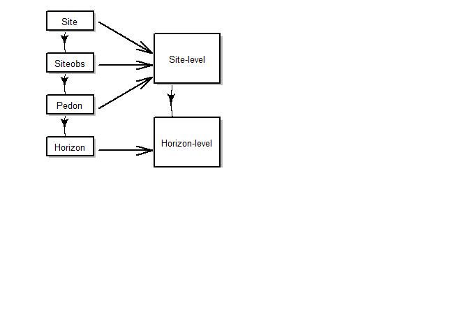

### Additional exploratory fetch functions in the soilDB package

- **fetchNASISLabData()**
  - KSSL laboratory pedon/horizon layer data from a local NASIS database.
- **fetchKSSL()**
  - Get KSSL data via BBOX, MLRA, or series name query, from the SoilWeb system.
- **fetchOSD()**
  - fetches a limited subset of horizon and site-level attributes for named soil series, from the SoilWeb system.
- **fetchRaCA()**
  - Get Rapid Carbon Assessment (RaCA) data by state, geographic bounding-box, RaCA site ID, or series query from the SoilWeb system.
- **fetchSCAN()**
  - Query soil/climate data from USDA-NRCS SCAN Stations (experimental)
- **fetchHenry()**
  - Download Data from the Henry Mount Soil Climate Database (experimental)
- **fetchPedonPC()**
  - Fetch commonly used site/horizon data from a PedonPC v.5 database.

### 2.2 Data checks run by the `fetchNASIS()` function

When loading pedons with the fetchNASIS() function the following data checks are performed:

- **presence of multiple map datums:** results reported to the user and the data are not modified
- **inconsistent horizon boundaries:** pedons with inconsistent horizon boundaries are not loaded. In most cases this occurs when the bottom depth of a horizon is not the same as the upper depth of the next lower horizon.

```
##   hzname top bot
## 1      A   0  30
## 2    Bt1  38  56
## 3    Bt2  56 121
## 4     Bk 121 135
## 5      R 135
```

Notice the issue here? Bottom depth of the A horizon and the upper depth of the Bt1 horizons should be the same - either be 30 or 38 cm? Need to determine which to correct this issue.

- **missing lower horizon depths:** offending horizons are fixed by replacing the missing bottom depth with the top depth + 2cm. So in the case of the profile shown above a bottom depth of 137cm would be inserted where the depth is missing.
- **sites missing pedon records:** data without corresponding horizons are not loaded

#### How can we find the site ID’s where these errors occur so that we can to fix them in NASIS?

Should errors in the pedon data be detected when loading data using fetchNASIS() you can use the following ‘get’ functions to trace them back to the records in NASIS:

- **get(‘sites.missing.pedons’, envir=soilDB.env)**
  - returns user site ID’s for sites missing pedons
- **get(‘dup.pedon.ids’, envir=soilDB.env)**
  - returns pedon ID’s for sites with duplicate pedon ID’s
- **get(‘bad.pedon.ids’, envir=soilDB.env)**
  - returns user pedon ID’s for pedons with inconsistent horizon depths
- **get(‘bad.horizons’, envir=soilDB.env)**
  - returns a dataframe of horizon-level information for pedons with inconsistent horizon depths

For more information on the design of soilDB functions use the following link to the soilDB documentation - [**Introduction to soilDB**](https://r-forge.r-project.org/scm/viewvc.php/%2acheckout%2a/docs/soilDB/soilDB-Intro.html?root=aqp)

### Options that can be set within fetchNASIS()

There are two default options that can be set within `fetchNASIS(rmHzErrors = TRUE, nullFragsAreZero = TRUE)`

- **rmHzErrors = TRUE/FALSE**
  - Setting this value to **TRUE** (the default) will enable checks for horizon depth consistency. Consider setting this argument to FALSE if you aren’t concerned about horizon depth errors, or know that your selected set contains many combination horizons. Note that any pedons flagged as having horizon depths errors (rmHzErrors = TRUE) will be omitted from the data returned by fetchNASIS().
- **nullFragsAreZero = TRUE/FALSE**
  - Setting this value to **TRUE** (the default) will convert NULL rock fragment volumes to 0s. This is typically the right assumption as rock fragment data are typically populated only when observed. If you know that your data contain a combination of ommited information (e.g. there are no rock fragment volumes populated) then consider setting this argument to FALSE.

For more information on the data checks and adjusting the default options to `fetchNASIS()` function use the following resource - [**Tips on getting data from NASIS into R**](https://r-forge.r-project.org/scm/viewvc.php/%2acheckout%2a/docs/soilDB/fetchNASIS-mini-tutorial.html?root=aqp)

### 2.3 The structure of pedon data stored in the Soil Profile Collection (SPC) object

#### The `Gopheridge` Sample Dataset

The `gopheridge` sample dataset is very similar to the type of data returned from `fetchNASIS()`. The following demonstration is intended to show the structure of the Soil Profile Collection (SPC) object that is returned by ‘fetchNASIS()’.

Before proceeding it may be helpful to review the [**SoilProfileCollection object introduction**](https://r-forge.r-project.org/scm/viewvc.php/*checkout*/docs/aqp/aqp-intro.html?root=aqp). This tutorial provides an excellent overview of how the SPC object is constructed. Also the `soilDB` and `aqp` manual pages are accessible by entering the following into the R console: `library(soilDB)` and then `help(soilDB)` `library(aqp)` and then `help(aqp)`

Open R, and setup the environment by loading packages and the Gopheridge sample dataset.

```r
library(soilDB)
library(aqp)

# load example dataset
data(gopheridge)

# what kind of object is this?
class(gopheridge)
```

```
## [1] "SoilProfileCollection"
## attr(,"package")
## [1] "aqp"
```

```r
# let's take a look at the fields at the site and horizon levels within the SPC
names(site(gopheridge))
```

```
##  [1] "peiid"                "pedon_id"             "siteiid"              "site_id"
##  [5] "obs_date"             "utmzone"              "utmeasting"           "utmnorthing"
##  [9] "x"                    "y"                    "datum"                "x_std"
## [13] "y_std"                "describer"            "pedon_purpose"        "pedon_type"
## [17] "pedlabsampnum"        "elev_field"           "slope_field"          "aspect_field"
## [21] "plantassocnm"         "coverkind_1"          "bedrckdepth"          "bedrock_kind"
## [25] "bedrock_hardness"     "hillslope_pos"        "slope_position"       "shapeacross"
## [29] "shapedown"            "slopecomplex"         "drainagecl"           "classdate"
## [33] "classifier"           "class_type"           "taxonname"            "taxon_kind"
## [37] "series_status"        "part_size_class"      "tax_order"            "tax_suborder"
## [41] "tax_grtgroup"         "tax_subgroup"         "tax_edition"          "osdtypelocflag"
## [45] "tax_moistureclass"    "tax_fam_other"        "psctopdepth"          "pscbotdepth"
## [49] "selection_method"     "ochric.epipedon"      "argillic.horizon"     "lithic.contact"
## [53] "paralithic.contact"   "cambic.horizon"       "limnic.materials"     "paralithic.materials"
## [57] "surface_fgravel"      "surface_gravel"       "surface_cobbles"      "surface_stones"
## [61] "surface_boulders"     "surface_channers"     "surface_flagstones"   "surface_paragravel"
## [65] "surface_paracobbles"  "landform.string"      "pmkind"               "pmorigin"
```

```r
names(horizons(gopheridge))
```

```
##  [1] "peiid"               "phiid"               "hzname"              "genhz"
##  [5] "hzdept"              "hzdepb"              "clay"                "silt"
##  [9] "sand"                "texture_class"       "texture"             "phfield"
## [13] "effervescence"       "labsampnum"          "total_frags_pct_cal" "total_frags_pct"
## [17] "rupresblkdry"        "stickiness"          "plasticity"          "d_r"
## [21] "d_g"                 "d_b"                 "d_hue"               "d_value"
## [25] "d_chroma"            "d_sigma"             "m_r"                 "m_g"
## [29] "m_b"                 "m_hue"               "m_value"             "m_chroma"
## [33] "m_sigma"             "soil_color"          "fine_gravel"         "gravel"
## [37] "cobbles"             "stones"              "boulders"            "paragravel"
## [41] "paracobbles"         "channers"            "flagstones"
```

```r
# show data
head(site(gopheridge), 2) # show the first 2 lines of the site data
```

```
##    peiid pedon_id siteiid       site_id            obs_date utmzone utmeasting utmnorthing
## 1 242808 07JCR002  244384 07CA630JCR002 2007-04-02 01:00:00      10   700783.0     4201935
## 2 268791 07JCR003  269602 07CA630JCR003 2007-05-14 01:00:00      10   714552.7     4191747
##           x        y datum     x_std    y_std describer          pedon_purpose
## 1 -120.7150 37.94286 NAD83 -120.7150 37.94286 John Rule full pedon description
## 2 -120.5614 37.84805 NAD83 -120.5614 37.84805 John Rule full pedon description
##                 pedon_type pedlabsampnum elev_field slope_field aspect_field      plantassocnm
## 1                OSD pedon       07N0469        337          20          272              <NA>
## 2 correlates to named soil          <NA>        324          15          154 Blue Oak Woodland
##   coverkind_1 bedrckdepth  bedrock_kind          bedrock_hardness hillslope_pos  slope_position
## 1          NA          81    Greenstone Extremely weakly cemented     Backslope on middle third
## 2          NA          60 Metavolcanics Extremely weakly cemented     Backslope            <NA>
##   shapeacross shapedown slopecomplex   drainagecl           classdate classifier class_type
## 1      Linear    Linear      complex Well drained 2012-01-24 01:00:00       <NA>     series
## 2      Convex    Convex         <NA> Well drained 2012-01-25 00:15:24       <NA>     series
##    taxonname taxon_kind series_status part_size_class tax_order tax_suborder tax_grtgroup
## 1 GOPHERIDGE     series          <NA>  loamy-skeletal  alfisols      xeralfs haploxeralfs
## 2 GOPHERIDGE     series          <NA>  loamy-skeletal  alfisols      xeralfs haploxeralfs
##         tax_subgroup   tax_edition osdtypelocflag tax_moistureclass tax_fam_other psctopdepth
## 1 ultic haploxeralfs tenth edition              1             xeric          <NA>          18
## 2 ultic haploxeralfs tenth edition              0             xeric          <NA>          15
##   pscbotdepth selection_method ochric.epipedon argillic.horizon lithic.contact paralithic.contact
## 1          68      most recent            TRUE             TRUE           TRUE              FALSE
## 2          58      most recent            TRUE             TRUE           TRUE              FALSE
##   cambic.horizon limnic.materials paralithic.materials surface_fgravel surface_gravel
## 1          FALSE            FALSE                FALSE               5             11
## 2          FALSE            FALSE                FALSE               0              0
##   surface_cobbles surface_stones surface_boulders surface_channers surface_flagstones
## 1               1              0                0                0                  0
## 2               0              0                0                0                  0
##   surface_paragravel surface_paracobbles landform.string               pmkind      pmorigin
## 1                  0                   0       hillslope colluvium & residuum    greenstone
## 2                  0                   0       hillslope colluvium & residuum metavolcanics
```

```r
head(horizons(gopheridge), 5) # show the first 5 rows of the horizon data
```

```
##    peiid   phiid hzname genhz hzdept hzdepb clay silt sand texture_class texture phfield
## 1 242808 1148313     Oi    NA      0      3   NA   NA   NA           spm     SPM      NA
## 2 242808 1148312     Oe    NA      3      5   NA   NA   NA           mpm     MPM      NA
## 3 242808 1148311     A1    NA      5     10   16   44   20           sil     SIL     6.4
## 4 242808 1148310     A2    NA     10     18   18   42   20           sil     SIL     6.1
## 5 242808 1148309    Bt1    NA     18     36   25   55   20           sil GRV-SIL     6.1
##   effervescence labsampnum total_frags_pct_cal total_frags_pct   rupresblkdry        stickiness
## 1          <NA>   07N03080                   0               0           <NA>              <NA>
## 2          <NA>   07N03080                   0               0           <NA>              <NA>
## 3          none   07N03081                   6               6           hard   slightly sticky
## 4          none   07N03082                  11              11      very hard   slightly sticky
## 5          none   07N03083                  63              63 extremely hard moderately sticky
##           plasticity       d_r       d_g       d_b d_hue d_value d_chroma d_sigma       m_r
## 1               <NA>        NA        NA        NA  <NA>      NA       NA      NA        NA
## 2               <NA>        NA        NA        NA  <NA>      NA       NA      NA        NA
## 3         nonplastic 0.5228873 0.3383394 0.2180537   5YR       4        5      NA 0.4137360
## 4   slightly plastic 0.5409717 0.3305930 0.1852933   5YR       4        6      NA 0.4268473
## 5 moderately plastic 0.5409717 0.3305930 0.1852933   5YR       4        6      NA 0.4268473
##         m_g       m_b m_hue m_value m_chroma m_sigma soil_color fine_gravel gravel cobbles stones
## 1        NA        NA  <NA>      NA       NA      NA       <NA>           0      0       0      0
## 2        NA        NA  <NA>      NA       NA      NA       <NA>           0      0       0      0
## 3 0.2412848 0.1342228   5YR       3        5      NA    #6A3E22           0      6       0      0
## 4 0.2319875 0.1567336 2.5YR       3        5      NA    #6D3B28           0     11       0      0
## 5 0.2319875 0.1567336 2.5YR       3        5      NA    #6D3B28           0     47      11      5
##   boulders paragravel paracobbles channers flagstones
## 1        0          0           0        0          0
## 2        0          0           0        0          0
## 3        0          0           0        0          0
## 4        0          0           0        0          0
## 5        0          0           0        0          0
```

### Follow along with your own data

```r
library(soilDB)
library(aqp)

# load data from a NASIS selected set
f <- fetchNASIS()

# what kind of object is this?
class(f)

# let's take a look at the fields at the site and horizon levels within the SPC
names(site(f))
names(horizons(f))

# look at the first 2 sites of the data
head(site(f), 2)
head(horizons(f), 2)
```

### Question:

#### How can we find out how many site and horizon records we have in the data we’ve just loaded?

uoᴉʇɔunɟ ()ɹʇs ǝɥʇ ǝsn

### 2.4 Viewing pedon locations

#### Plotting geographic data directly in R

- **Quick check:** Does the data roughly plot where you would expect it to?

Plotting the data directly as an R graphic can give you some idea of how the data look spatially and whether their distribution approximates what you would expect to see. Typos in coordinates are relatively common when they are manually entered and viewing the data spatially is a very quick way to see points that plot way outside of the geographic area of interest and clearly have some kind of error.

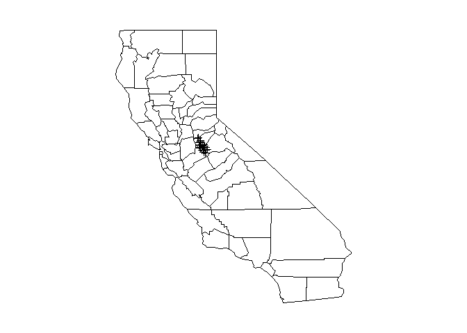

```r
# plot the locations of the gopherridge pedons within R
# Steps:
# 1) subset to a new data frame
# 2) create a spatial points data frame (SPDF)
# 3) plot the data

# load libraries
library(sp)
library(maps)

# subset standard WGS84 decimal degree coordinates from the gopheridge SPC by specifying column names
gopher.locations <- site(gopheridge)[, c('site_id', 'x_std', 'y_std')]

# initialize coordinates in an SPDF
coordinates(gopher.locations) <- ~ x_std + y_std

# set plot margins
par(mar=c(0,0,0,0))

# plot county boundaries for all of CA
map('county', 'california', fill = FALSE)
# add plot of pedon data locations
plot(gopher.locations, add = TRUE)
```

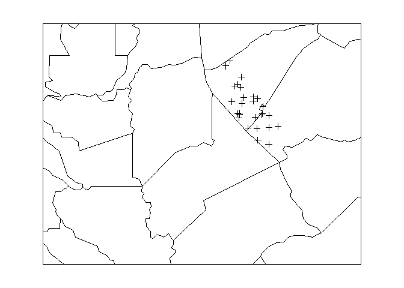

```r
# plot again but zoom in by setting xlim, ylim extents
map('county', 'California', xlim=c(-122.25, -119.75), ylim=c(37, 38.5))

# add plot of pedon data locations
plot(gopher.locations, add = TRUE)
box()
```

#### Displaying pedon data in Google Earth

Google Earth is a powerful data viewer for point data. Geographic data in Google Earth is displayed using the Keyhole Markup Language (KML) format. Using the [plotKML](https://cran.r-project.org/web/packages/plotKML/plotKML.pdf) package we can easily create a KML file for inspection and viewing in Google Earth. See the related material in this tutorial [**Export Pedons to Google Earth**](https://r-forge.r-project.org/scm/viewvc.php/*checkout*/docs/soilDB/export-points-from-NASIS-to-Google-Earth.html?root=aqp).

#### Exporting pedon data to an ESRI shapefile

Another way we could view the data is to export a shapefile from R. Further information on how to do this can be found in this tutorial [**Export Pedons to Shapefile**](https://r-forge.r-project.org/scm/viewvc.php/*checkout*/docs/soilDB/export-points-from-NASIS.html?root=aqp).

### Exercise:

#### Use the following script to make an R plot of pedon data you’ve loaded from your NASIS selected set.

The following script is plotting the standard lat/long fields from NASIS. In some cases you might find that these fields are incomplete due to insufficient data or have not been calculated from UTM coordinates in NASIS. In these cases there are a couple of ways that you can omit sites with ‘NA’ values in the coordinates. `na.omit()` or `complete.cases()` functions will remove any rows in a dataframe that have ‘NA’ values.

```r
# load libraries
library(sp)
library(maps)

# subset standard WGS84 decimal degree coordinates from the gopheridge SPC by specifying column names
f.locations <- site(f)[, c('site_id', 'x_std', 'y_std')]

# remove any sites lacking standard lat/long coordinates
f.locations <- na.omit(f.locations)

# initialize coordinates in an SPDF
coordinates(f.locations) <- ~ x_std + y_std

# set plot margins
par(mar=c(0,0,0,0))

# plot pedon locations
plot(f.locations)

# plot again this time with county boundaries for your state
# ENTER your state!!!
map('county', 'Montana', fill = FALSE)
# add plot of pedon locations
plot(f.locations, add = TRUE)
```

### 2.5 Working with SPC data in R

#### Summarizing data

Now that we’ve loaded some data, let’s look at additional ways that you can summarize data elements and filter the SPC to specific sites of interest. The `table()` function is very useful for quick summary operations. This function can be combined with other functions such as `sort()` and `is.na()` or `!is.na()` (is not NA). Follow along with your own data.

```r
# summarize which soil taxa we have loaded
table(f$taxonname)
# sort results in descending order
sort(table(f$taxonname), decreasing=TRUE)

# could do the same thing for taxonomic subgroups or any column of the SPC at the site or horizon levels
table(f$tax_subgroup)
sort(table(f$tax_subgroup), decreasing=TRUE)

# table() is also useful when testing for null data using IS NA, is.na() or IS NOT NA, !is.na()
table(is.na(f$tax_subgroup))
table(!is.na(f$tax_subgroup))

# it can also be applied to horizon level columns in the SPC
sort(table(f$texture), decreasing=TRUE)
```

#### Filtering data using pattern matching

A collection of soil profiles or an SPC can be subset using a variety of methods and then the results can be placed into another SPC. This can be useful for generating subset SPC objects from the original dataset. The following examples use the `grep()` function to pattern match within the data and create an index of the SPC for records that match the specified pattern within that column and then use that index to filter to specific sites and their corresponding profiles.

This process can be applied to many different columns in the SPC based on how you need to filter the data. This example pattern matches on the `tax_subgroup` column, but another useful application might be to pattern match on geomorphic or parent material information.

The soilDB package flattens the nested table structure of parent material and geomorphic description within NASIS into single strings per site-level record. Pattern matching can be used to select profiles based on parts of these strings.

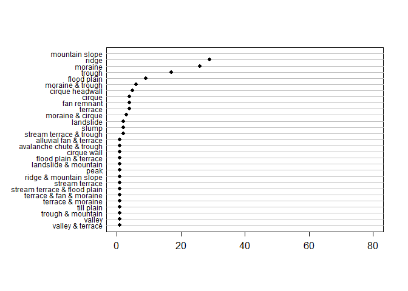

```r
# graphically tabulate the occurrence of landforms
# load library for dotchart2()
library(Hmisc)
# create 'lf' object of landform factors sorted in descending order
lf <- sort(table(f$landform.string), decreasing = TRUE)
# plot dotchart
dotchart2(lf, col='black', xlim = c(0, 80), cex.labels = 0.75)
```

Notice below that the `grep()` also has an *invert option*, which is specified as either TRUE or FALSE (the default when unspecified is FALSE). This option is very useful for excluding the results of the pattern matching process by inverting the selection.

```r
# say we wanted to look at what the variation of particle size classes are within a specific subgroup?
# use of grep() to filter and create an index, then apply that index to the SPC
# and create a new SPC called 'f1' using the square bracket notation
idx <- grep('lithic', f$tax_subgroup, invert=FALSE)
# save this subset of 'lithic' soils for later use
f1 <- f[idx, ]
# or use the index directly to summarize a field
sort(table(f$part_size_class[idx]), decreasing=TRUE)
```

Let’s do a quick graphical check that we’ve selected the ’lithic*’ profiles by plotting them in R using the AQP package `plot()` function.

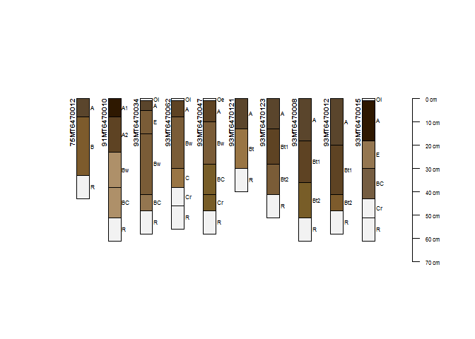

```r
# plot the first 10 profiles of the 'f1' subset
plot(f1[1:10, ], label='site_id')
```

For more information on using regular expressions in `grep()` for pattern matching operations: (https://www.gnu.org/software/findutils/manual/html_node/find_html/grep-regular-expression-syntax.html)

#### Filtering data by specifying a criteria using the `which()`

Another method of subsetting a collection of soil profiles is to specify a criteria using the `which()` function. The following examples use the `which()` and `grep()` functions to reference the indexing of the SPC to create subsets and to filter to specific sites or their corresponding profiles.

```r
# say we wanted to look at what the variation of particle size classes are within a specific subgroup?
# first: use grep to pattern match the tax_subgroup field for the string 'aqu'
idx <- grep('aqu', f$tax_subgroup)
# save this subset
f1 <- f[idx, ]
# check taxonomic range of particle size classes in the data
sort(table(f1$tax_subgroup), decreasing=TRUE)
```

```
##
##       typic cryaquents      histic cryaquepts  oxyaquic cryofluvents    aquandic cryaquepts
##                      8                      6                      4                      2
##   oxyaquic cryochrepts oxyaquic dystrocryepts       aeric cryaquepts     histic endoaquolls
##                      2                      2                      1                      1
##       humic cryaquepts    oxyaquic hapludolls   oxyaquic haplustalfs  oxyaquic vitricryands
##                      1                      1                      1                      1
##       typic cryaquepts      typic endoaquolls
##                      1                      1
```

```r
sort(table(f1$part_size_class), decreasing=TRUE)
```

```
##
##                            sandy-skeletal                              coarse-loamy
##                                        11                                         6
##                            loamy-skeletal                                fine-loamy
##                                         5                                         3
##                                fine-silty                clayey over loamy-skeletal
##                                         2                                         1
## coarse-loamy over sandy or sandy-skeletal   fine-loamy over sandy or sandy-skeletal
##                                         1                                         1
##   fine-silty over sandy or sandy-skeletal                                     sandy
##                                         1                                         1
```

```r
# then further query the subset for only those profiles with particle size class of 'sandy-skeletal'
# notice: a double equal sign '==' is used for exact character or numeric criteria
idx <- which(f1$part_size_class == 'sandy-skeletal')
# save this subset
f2 <- f1[idx, ]
# or use the index directly to summarize a field
sort(table(f2$part_size_class), decreasing=TRUE)
```

```
## sandy-skeletal
##             11
```

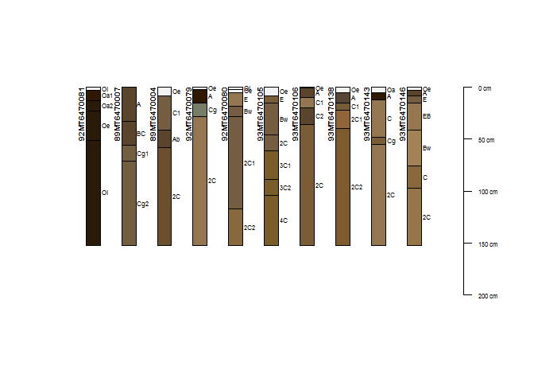

```r
# plot  profiles 1 thru 10
plot(f1[1:10, ], label='site_id')
```

#### Additional syntax options for use in `which()` criteria

- `%in%` - equivalent to IN() in SQL. Can use `c()` to concatenate lists of vectors
  - example: which(f$part_size_class %in% c(‘loamy-skeletal’, ‘sandy-skeletal’))
- `!=` - not equal to character ‘string’
- `==` - notice in the above example that R uses a double equal sign as equal to.
- `<, >, <=, >=` - less than, greater than, and equal to.

### Extracting Site and Horizon data

Soil Profile Collections are designed to be dismantled in order to work with either site or horizon data more easily. Within the SPC there is a slot for site-level data and a slot for horizon-level data. We can reference these slots using the `site()` and `horizons()` functions within the AQP package. These getter functions will extract all the site or horizon variables as a dataframe for further use.

```r
# extract site data from SPC into dataframe 's'
s <- site(f)
names(s)
```

```
##  [1] "peiid"                 "pedon_id"              "siteiid"               "site_id"
##  [5] "obs_date"              "utmzone"               "utmeasting"            "utmnorthing"
##  [9] "x"                     "y"                     "datum"                 "x_std"
## [13] "y_std"                 "gpspositionalerror"    "describer"             "pedon_purpose"
## [17] "pedon_type"            "pedlabsampnum"         "labdatadescflag"       "elev_field"
## [21] "slope_field"           "aspect_field"          "plantassocnm"          "coverkind_1"
## [25] "bedrckdepth"           "bedrock_kind"          "bedrock_hardness"      "hillslope_pos"
## [29] "slope_position"        "shapeacross"           "shapedown"             "slopecomplex"
## [33] "drainagecl"            "classdate"             "classifier"            "class_type"
## [37] "taxonname"             "taxon_kind"            "series_status"         "part_size_class"
## [41] "tax_order"             "tax_suborder"          "tax_grtgroup"          "tax_subgroup"
## [45] "tax_edition"           "osdtypelocflag"        "tax_moistureclass"     "temp_class"
## [49] "tax_fam_other"         "psctopdepth"           "pscbotdepth"           "selection_method"
## [53] "andic.soil.properties" "mollic.epipedon"       "cambic.horizon"        "surface_fgravel"
## [57] "surface_gravel"        "surface_cobbles"       "surface_stones"        "surface_boulders"
## [61] "surface_channers"      "surface_flagstones"    "surface_paragravel"    "surface_paracobbles"
## [65] "landform.string"       "pmkind"                "pmorigin"
```

```r
# extract horizon data from SPC into dataframe 'h'
h <- horizons(f)
names(h)
```

```
##  [1] "peiid"               "phiid"               "hzname"              "genhz"
##  [5] "hzdept"              "hzdepb"              "clay"                "silt"
##  [9] "sand"                "texture_class"       "texture"             "phfield"
## [13] "effervescence"       "labsampnum"          "total_frags_pct_cal" "total_frags_pct"
## [17] "rupresblkdry"        "stickiness"          "plasticity"          "d_r"
## [21] "d_g"                 "d_b"                 "d_hue"               "d_value"
## [25] "d_chroma"            "d_sigma"             "m_r"                 "m_g"
## [29] "m_b"                 "m_hue"               "m_value"             "m_chroma"
## [33] "m_sigma"             "soil_color"          "fine_gravel"         "gravel"
## [37] "cobbles"             "stones"              "boulders"            "paragravel"
## [41] "paracobbles"         "channers"            "flagstones"
```

We can also use these functions in referencing the data within an SPC to specify that we want to look specifically in the site or horizon data.

### Review of data checks run by `fetchNASIS()`

Now that we’ve loaded some data and learned a little about how to filter data in the SPC, let’s quickly review some of the `get()` functions used to track data issues detected in the process of loading back to records in our selected set.

```r
# use each one of these to return a vector of the pedons where errors were detected
#get('sites.missing.pedons', envir=soilDB.env)
#get('dup.pedon.ids', envir=soilDB.env)
#get('bad.pedon.ids', envir=soilDB.env)
# example of pedon_id's returned
#[1] "2011MT0810001" "2011MT0810009" "2011MT00810015" "2011MT0810027" "2011MT0810034"

# How could you then remove these from your SPC?
# since the get() returns the string of bad pedon id's we can use a which() to query pedon id's that don't match the bad id's
idx <- which(horizons(f)$pedon_id != get('bad.pedon.ids', envir=soilDB.env))
f <- f[idx, ]
```

Another useful function is `dput()` which will concatenate a variable converting something like this:  
“2011MT0810001” “2011MT0810009” “2011MT00810015” “2011MT0810027” “2011MT0810034”  
Into this:  
c(“2011MT0810001”, “2011MT0810009”, “2011MT00810015”, “2011MT0810027”, “2011MT0810034”)

Such a string can then be copy/pasted back as a concatenated string or could even be used as string for NASIS list queries.

### Logical evaluations using `ifelse()`

Often there are operations in which we need to evaluate the site or horizon data and assign some variable using a logic statment. One way to do this is to use the `ifelse()` function. The following shows some examples of how to do this.

```r
# assigning a variable using a logical statement
# standard format
#    ifelse(variable == '', then do, else do)
# can also nest these statements
#     ifelse(variable == '', then do...., ifelse(variable == '', then do..., else do....))
# TODO: combine with the use of paste() in this example
```

### Custom functions

Functions can bundle a series of operations and then be applied to an SPC using `profileApply()`. Say we wanted use some pedon data to model the depth to calcium carbonate. One way to do this would be to look through horizon designations to derive a depth to calcium carbonate using the ‘k’ suffix designation. A first step to doing something like this would be to think about outlining the steps involved in the process.

What steps would be needed to accomplish this task and return an upper depth to carbonates for each site?

- *extract* the horizon data for each profile
- *iterate* through the horizon designations(hzname) pattern matching for ‘k’
- *apply* the function to each profile via `profileApply()`
- *summarize* the data returned by the function to one value per profile
- *join* the summarized depth value back to the site data

```r
# load library
library(plyr)

f.limy <- function(i) {
  # extract horizons
  h <- horizons(i)

  # pattern match for 'k' horizon designations in horizon data
  h2 <- h[grep('k', h$hzname, invert=FALSE), ]

  # return data
  return(data.frame(peiid=h2$peiid, phiid=h2$phiid, hzname=h2$hzname, hzdept=h2$hzdept, hzdepb=h2$hzdepb, ph=h2$phfield, efferv=h2$effervescence))
}

# apply function to each profile, results are a list of data.frames
l <- profileApply(f, FUN=f.limy, simplify=FALSE)

# convert list into a dataframe
limy <- ldply(l)

# show contents of the limy dataframe
head(limy)

# example of data returned - you can see that we still need to summarize this to get the upper depth from multiple 'Bk' horizons
# notice that a couple of additional variable were return by the function
#     .id  peiid   phiid hzname hzdept hzdepb ph_0_18 efferv_0_18
#1 828198 828198 4268004    Bk1     91    152     8.2     violent
#2 828198 828198 4268003    Bk2    152    182     8.2      strong
#3 828209 828209 4268070    Btk    104    152     7.6       <NA>

# still need to reduce this down to one depth value for each profile
# summarize this dataframe using summarise() in the plyr package
#TODO: provide general example of syntax for ddply() here!
##
limy1 <- ddply(limy, 'peiid', summarise, depth_to_carbonates_cm=min(hzdept))

# since we have peiid in the limy1 dataframe we can easy join it back to site data in the SPC
site(f) <- limy1

# summary of depth to carbonates in the data
table(f$depth_to_caco3_cm)
```

### Question:

#### What is a potential problem with this operation? What was not accounted for?

#### TODO: provide another example - this time going after O horizon thickness

#### Or a more complicated example truncating thickness at 100cm below the mineral soil surface

TODO: The above function examples will only work if your pedon data has carbonates or argillic horizons…..work up a parallel example that goes for depth to argillic using gopheridge or loafercreek datasets (neither of these sets have carbonates!).

### Getting additional data: Extended data functions in soilDB

Additional data related to both site and horizon information can be fetched using the `get_extended_data_from_NASIS()` function. The reason that this data is not automatically brought into R is that in most cases these data elements are related to the site or horizon data as one to many relationships. Multiple diagnostic features could exist within one pedon for example. Below is a summary of additional information that can be readily brought into R from your NASIS selected set via the `get_extended_data_from_NASIS()` function.

```r
# fetch extended site and horizon data
e <- get_extended_data_from_NASIS_db()

### site and pedon related extended data
# vegetation data summary
colnames(e$veg)
##  [1] "siteiid"               "vegplotid"             "vegplotname"           "obsdate"
##  [5] "primarydatacollector"  "datacollectionpurpose" "assocuserpedonid"      "seqnum"
##  [9] "plantsym"              "plantsciname"          "plantnatvernm"         "orderofdominance"
## [13] "speciescancovpct"      "speciescancovclass"
# diagnostic features
colnames(e$diagnostic)
## [1] "peiid"     "diag_kind" "featdept"  "featdepb"
# surface rock fragments
colnames(e$surf_frag_summary)
##  [1] "peiid"               "surface_fgravel"     "surface_gravel"      "surface_cobbles"
##  [5] "surface_stones"      "surface_boulders"    "surface_channers"    "surface_flagstones"
##  [9] "surface_paragravel"  "surface_paracobbles"
# geomorphic description
colnames(e$geomorph)
## [1] "peiid"        "geomfmod"     "geomfname"    "geomfeatid"   "existsonfeat" "geomfiidref"
## [7] "geomftname"
# taxonomic history data
colnames(e$taxhistory)
##  [1] "peiid"             "classdate"         "classifier"        "class_type"
##  [5] "taxonname"         "taxon_kind"        "series_status"     "part_size_class"
##  [9] "tax_order"         "tax_suborder"      "tax_grtgroup"      "tax_subgroup"
## [13] "tax_edition"       "osdtypelocflag"    "tax_moistureclass" "temp_class"
## [17] "tax_fam_other"     "psctopdepth"       "pscbotdepth"
# linked photo stored in site textnotes
colnames(e$photo)
## [1] "siteiid"   "recdate"   "textcat"   "imagepath"
# site parent materials
colnames(e$pm)
##  [1] "siteiid"       "seqnum"        "pmorder"       "pmdept"        "pmdepb"        "pm_modifier"
##  [7] "pmgenmod"      "pm_kind"       "pm_origin"     "pm_weathering"

### horizon related extended data
# rock fragments
colnames(e$frag_summary)
##  [1] "phiid"       "fine_gravel" "gravel"      "cobbles"     "stones"      "boulders"
##  [7] "paragravel"  "paracobbles" "channers"    "flagstones"
# soil texture modifers
colnames(e$texmodifier)
## [1] "peiid"            "phiid"            "phtiid"           "seqnum"           "texture_modifier"
# soil structure data
colnames(e$struct)
## [1] "phiid"           "structure_grade" "structure_size"  "structure_type"  "structid"
## [6] "structpartsto"
```

### Thicknesses of diagnostic features

#### Boolean diagnostic feature columns in the site data

If diagnostic features have been populated in the pedon diagnostic features table in NASIS then data brought into R by soilDB will have boolean (true or false) fields created for each diagnostic feature present in the data. These fields can be readily used to model the presence/absence of a diagnostic soil feature by extracting the site data.

We could have used the following code to pull the upper depth to calcium carbonates using the ‘calcic horizon’ and/or the ‘secondary carbonates’ diagnostic features. However, this is where data consistency becomes critical. We could only use those fields if they have been consistently populated for all pedons that we are working with in our selected set. As you start working with larger pedon data sets you will quickly find that there can be great inconsistencies in the way the data was populated by different people in different offices on different surveys over different timeframes.

The following is an example of how you could use the diagnostic features (if populated!) from the extended data to determine the thickness of some diagnostic feature of interest:

```r
# fetch extended site and horizon data
e <- get_extended_data_from_NASIS_db()

# get the thickness of a diagnostic feature - in this case an argillic horizon
###get upper and lower depths for a diagnostic
d <- e$diagnostic[e$diagnostic$diag_kind == 'argillic horizon', c('peiid', 'featdept', 'featdepb')]
# create a column of argillic thickness
d$argillic_thickness_cm <- d$featdepb - d$featdept
# omit NA values
d <- na.omit(d)
# subset to remove featdept and featdepb columns from the dataframe
d <- d[, c('peiid', 'argillic_thickness_cm')]
# join these data with existing site data
site(f) <- d$argillic_thickness_cm
```

#### TODO: show how Boolean fields can be used in this process

### Question:

#### What can we do with the boolean diagnostic feature data?

#### Diagnostic feature diagrams

```r
## work up diagnostic plot based on gopheridge dataset
library(aqp)
library(soilDB)
library(sharpshootR)

# load data
data(gopheridge)

# select a series of diagnostic properties to consider or automatically pull diagnostic feature columns
# get all diagnostic feature columns from the site data by pattern matching on '[.]' in the colnames
idx <- grep('[.]', colnames(site(gopheridge)))
v <- colnames(site(gopheridge))[idx]
# remove 'landform.string' from this vector using negative index
idx <- which(v == 'landform.string')
v <- v[-idx]
v
```

```
## [1] "ochric.epipedon"      "argillic.horizon"     "lithic.contact"       "paralithic.contact"
## [5] "cambic.horizon"       "limnic.materials"     "paralithic.materials"
```

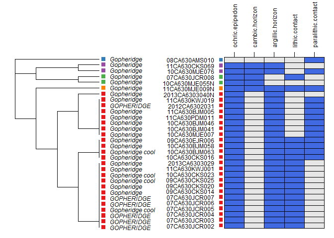

```r
# can limit which diagnostic to show by setting 'v', but might also be nice to have control of the order?
v <- c('ochric.epipedon', 'cambic.horizon', 'argillic.horizon', 'lithic.contact', 'paralithic.contact')

# generate diagnostic property diagram
diagnosticPropertyPlot(gopheridge, v, k=5, grid.label='site_id', dend.label = 'taxonname', sort.vars = FALSE)
```

```r
# another version of this diagram is possible
# diagnosticPropertyPlot2(gopheridge, v, k=5, grid.label='bedrock_kind')
```

### Exercise:

#### Use the following script to make a diagnostic feature diagram of the pedon data you’ve loaded from your NASIS selected set.

```r
library(soilDB)
library(sharpshootR)

# load data
f<- fetchNASIS()

# insert diagnostics of interest that relate to your data
v <- c('ochric.epipedon', 'cambic.horizon', 'argillic.horizon', 'lithic.contact', 'paralithic.contact')

# generate diagnostic property diagram
diagnosticPropertyPlot(f, v, k=5, grid.label='site_id', dend.label = 'taxonname')
```

For more information on generating diagnostic feature diagrams use the following tutorial: [**Diagnostic feature property plots**](https://r-forge.r-project.org/scm/viewvc.php/*checkout*/docs/sharpshootR/diagnostic-property-plot.html?root=aqp)

### 2.6 Consistency checking pedon data using R

#### assumptions:

[**Dealing with Troublesome data**](https://r-forge.r-project.org/scm/viewvc.php/*checkout*/docs/aqp/dealing-with-bad-data.html?root=aqp)

##### TODO: points to touch on further……

- some common pit falls of working with pedon data
- summarize this with some key words, consistency, confidence, style, legacy vintage, location data, etc then elaborate on aspects of each issue. Stress the importance of capturing pedon data observations.
- consistency in data population is key!
- horizonation issues, etc
- missing data
- weakening confidence with depth described - using a cutoff depth of 100cm for example to truncate observations to a zone of greater confidence - should use a slab plot to show this!!!

#### Remaining items to cover….probably more than this!

##### TODO: need clean up section to go over these!

- removing an object from R using rm() - may already have been covered in chapter 1?
- removing a column from a dataframe (d$bot <- NULL)
- negative indexes and what you can do with them - f[-idx, ], etc - add to filtering section….DONE! used this in the diagnostic plot section.

### 2.7 References

Package ‘aqp’ manual - (https://cran.r-project.org/web/packages/aqp/aqp.pdf)

Package ‘soilDB’ manual -(https://cran.r-project.org/web/packages/aqp/soilDB.pdf)

Package ‘sharpshootR’ manual -(https://cran.r-project.org/web/packages/aqp/sharpshootR.pdf)

### 2.8 Additional resources

**Quick R website**(http://www.statmethods.net/)

**Simple R tutorial**(http://cran.r-project.org/doc/contrib/Verzani-SimpleR.pdf)